# CSF_Spectronaut_sample_swap data visualization

Explicit rebuilt sample-swap data compared with the unswapped CSF reference

This vignette applies the same diagnostic structure as `CSF_Spectronaut_data_vis.qmd`, but uses the explicit rebuilt `CSF_Spectronaut_sample_swap` data as the after-swap state. The purpose is to check whether this materialized sample-swap file preserves the same H0/H1 variance behaviour as the authors’ in-script MSstats benchmark swap.

All quantitative panels in this document read the **Spectronaut report files directly**. Intensities come from `FG.Quantity`, are transformed with `log2`, deduplicated at `(run, protein, precursor)`, and then averaged to one protein-level value per run before fold changes and SDs are computed. No MSstats RDA object is used in this vignette.

# Truth-file consistency

The explicit `Report.tsv` was generated from a ground-truth file. This check compares that embedded generation truth with the current canonical `CSF_protein_swap_list.csv` in the folder.

The table must show identical row counts and zero label mismatches. If it does not, the explicit `Report.tsv` and the current truth file are out of sync and the Positive/Negative figures below are not interpretable.

Consistency check between the current canonical truth and the truth used to generate the explicit sample-swap file.

| check | value |
| --- | --- |
| current canonical truth rows | 2244 |
| embedded generation truth rows | 2244 |
| shared proteins | 2244 |
| label mismatches on shared proteins | 0 |
| current Positives labelled Negative in embedded truth | 0 |
| current Negatives labelled Positive in embedded truth | 0 |

# Acquisition schedule

This figure shows the Good-run subset used in the explicit sample-swap file. The points are runs from `CSF_Spectronaut_sample_swap/good_data/annotation.csv`. Curves show the same alternating run pairs used to rewrite Negative-protein rows in the generated Spectronaut report. The data plotted later are read from `CSF_Spectronaut_sample_swap/good_data/Report.tsv`.

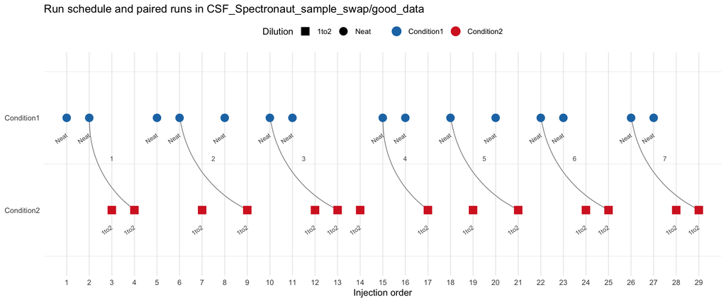

# Heatmap of the explicit sample-swap file

This heatmap uses direct report-derived protein/run intensities. For each run, precursor-level `FG.Quantity` values are log2-transformed and averaged to one value per protein. Rows are proteins from the current sample-swap truth list; columns are Good runs. Values are row-z-scored within protein. Positive proteins should keep the Condition1/Condition2 abundance pattern, while Negative proteins should lose the mean contrast after the explicit sample swap.

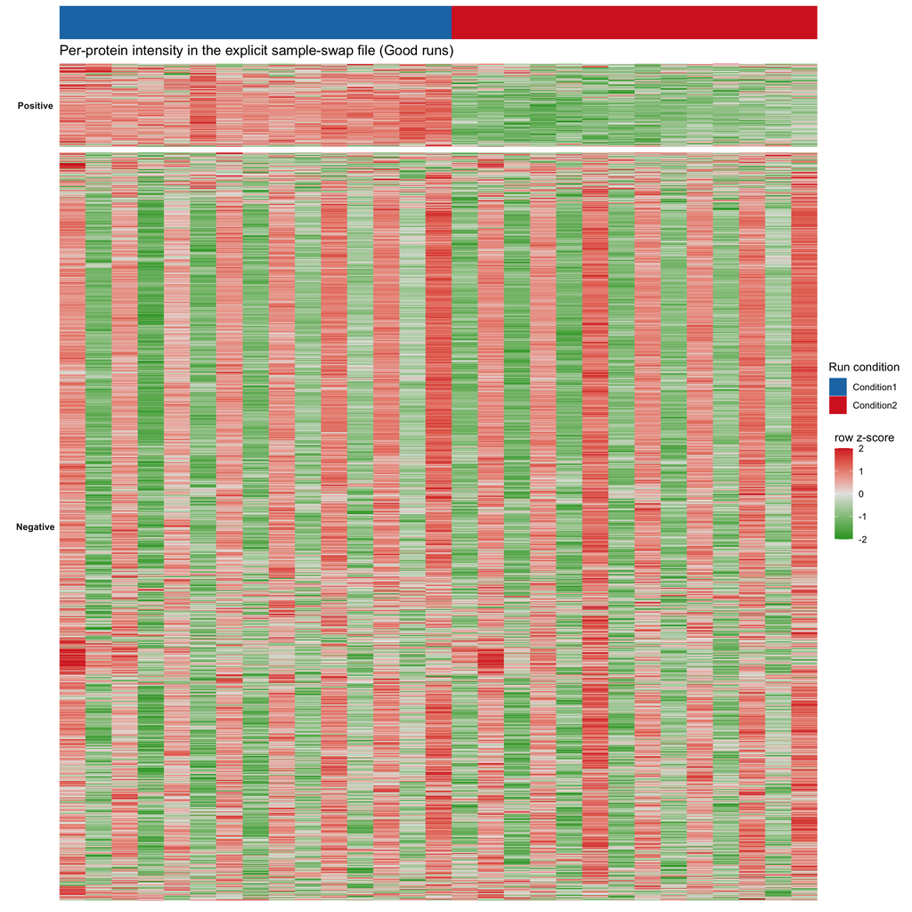

# Per-protein effect size and within-condition variance

The following panels summarize the same direct report-derived protein/run matrix. The before panel uses the unswapped `CSF_Spectronaut/good_data/Report.tsv` as a reference. The after panel uses the regenerated explicit `CSF_Spectronaut_sample_swap/good_data/Report.tsv`. The effect size is mean log2 intensity in Condition1 minus Condition2. The pooled SD is computed from within-condition SDs across runs.

Pooled within-condition SD summary for the rebuilt explicit sample-swap data.

| state | class | proteins | median_sd | mean_sd | q25_sd | q75_sd |
| --- | --- | --- | --- | --- | --- | --- |
| before swap reference | Negative | 2020 | 0.375 | 0.476 | 0.258 | 0.619 |
| after explicit sample-swap file | Negative | 2020 | 0.672 | 0.738 | 0.598 | 0.822 |
| before swap reference | Positive | 224 | 0.408 | 0.515 | 0.288 | 0.670 |
| after explicit sample-swap file | Positive | 224 | 0.408 | 0.515 | 0.288 | 0.670 |

## Effect size

This density plot checks the main sample-swap objective. Before swapping, both classes carry the CSF dilution effect. After the explicit sample swap, Negative proteins should be centered near zero, while Positive proteins should remain near the original one-log2 dilution effect.

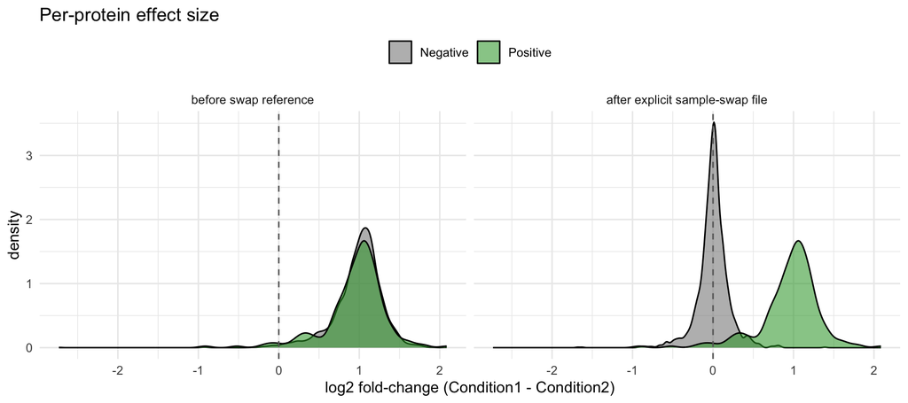

## Within-condition standard deviation

This density plot checks the variance consequence of the sample swap. After the explicit swap, Negative proteins should have larger pooled SD than Positive proteins, because each condition contains a mixture of Neat and 1:2 measurements for Negative proteins. Positive proteins are not swapped.

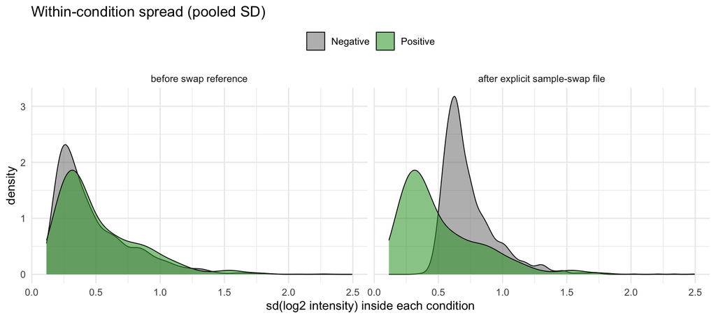

## Mean-variance relationship in the explicit sample-swap file

This plot shows the after-swap direct report-derived protein/run matrix. Each point is one protein. The x-axis is mean log2 intensity and the y-axis is pooled within-condition SD. Separation of Positive and Negative trends means the explicit file reproduces the label-dependent variance structure.

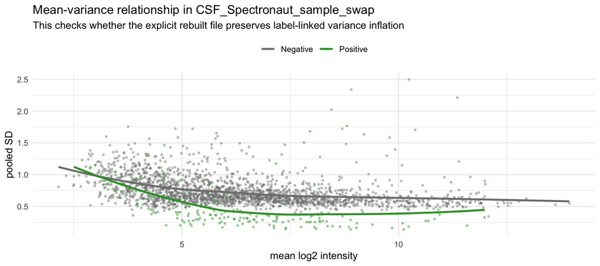